# Getting Started

Christina Maimone

1/10/2020

# RStudio Tour

- What is RStudio
- What are the different panes for?
- Console
  - up arrow for previous commands
  - () for grouping `(3+1)\*4`
  - Call a function: `round(2.1)`, `log(16)`, `round(log(16))`, `round(log(16), 2)`
  - assign a value: `x <- 3` >> shows up in environment
  - vector: `x <- c(1, 4, 3, 2, 5)`
  - history
  - case sensitive
  - spaces don’t matter
  - line continuation, escaping
  - Getting stuck with +
- Files
  - `getwd()`, `setwd()`
  - Projects
  - Send code from file to console
    - Send a comment line and it sends the line below
    - Sends a full command, even over multiple lines
  - New Files
    - Different types: R script, R Markdown, R Notebook
    - Comment character
  - Red, * for files with unsaved changes
- Packages
  - installing
  - loading

Cheatsheet: under Help > Cheatsheets > Browse Cheatsheets

# Do Something!

## Get Data

Import a data set. Rows are observations, columns are variables.

```r
library(readr)  # makes importing data a bit easier

africa <- read_csv("africadata.csv")  # works because this file is in my working directory
# if you haven't downloaded this file and the data file, read from the internet instead:
africa <- read_csv("https://nuitrcs.github.io/mmss211R/africadata.csv")
africa
```

```
## # A tibble: 53 x 7
##    country                region     gdp_2017 pop_2017    area  rail   road
##    <chr>                  <chr>         <dbl>    <dbl>   <dbl> <dbl>  <dbl>
##  1 Algeria                north   99722535234 41063753 2381740  4691 1.14e5
##  2 Angola                 central 31374141168 26655513 1246700    NA 5.14e4
##  3 Benin                  west     4732594367 11458611  114760   758 1.90e4
##  4 Botswana               south   11443275218  2343981  581730   888 2.58e4
##  5 Burkina Faso           west     7013022439 19173322  274220   622 1.53e4
##  6 Burundi                east     1215021410 11936481   27830    NA 1.23e4
##  7 Cameroon               central 17940338306 24513689  475440   977 2.89e4
##  8 Cape Verde             west     1129263677   533468    4030    NA 1.35e3
##  9 Central African Repub… central   873967756  5098826  622980    NA 2.03e4
## 10 Chad                   central  4150723012 14965482 1284000    NA 4.00e4
## # … with 43 more rows
```

- What are the `NA` values in the rail column?
- What are the numbers to the left of the country names?
- What is a tibble?

```r
View(africa)
```

## Plot

What is the distribution of country sizes? Use the area variable (column).

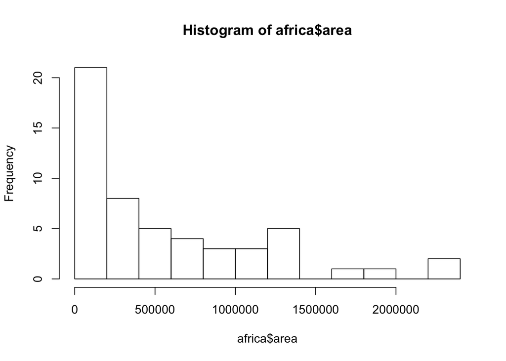

```r
hist(africa$area, breaks=15)
```

Or, using `ggplot2` and `dplyr` packages (from the `tidyverse`):

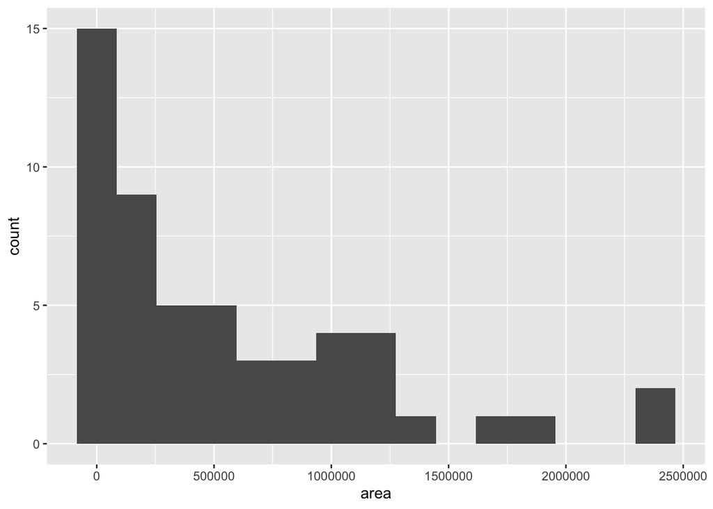

```r
library(tidyverse)  # loads multiple packages, including ggplot2 and dplyr
africa %>%
  ggplot(aes(area)) +
  geom_histogram(bins=15)
```

- What is `%>%`?
- Why is there a `+`?
- What is `aes()`

Why `ggplot2`?

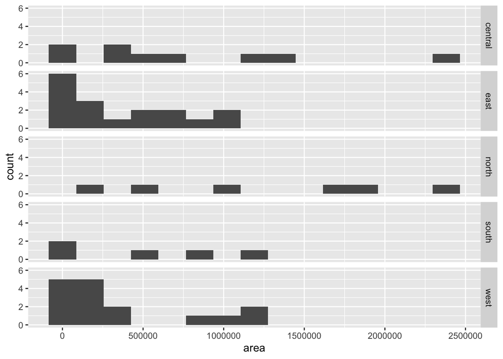

```r
africa %>%
  ggplot(aes(area)) +
  geom_histogram(bins=15) +
  facet_grid(region~.)
```

## Summarize

```r
mean(africa$area)
```

```
## [1] 555149.1
```

```r
mean(africa$rail)
```

```
## [1] NA
```

```r
mean(africa$rail, na.rm=TRUE)
```

```
## [1] 2341.742
```

```r
summary(africa)
```

```
##    country             region             gdp_2017
##  Length:53          Length:53          Min.   :1.180e+08
##  Class :character   Class :character   1st Qu.:2.055e+09
##  Mode  :character   Mode  :character   Median :6.069e+09
##                                        Mean   :2.190e+10
##                                        3rd Qu.:1.794e+10
##                                        Max.   :2.104e+11
##
##     pop_2017              area              rail            road
##  Min.   :    97539   Min.   :    460   Min.   :  259   Min.   :   320
##  1st Qu.:  2568569   1st Qu.:  56790   1st Qu.:  781   1st Qu.: 10600
##  Median : 12159586   Median : 322460   Median :  953   Median : 19418
##  Mean   : 23239288   Mean   : 555149   Mean   : 2342   Mean   : 44070
##  3rd Qu.: 26655513   3rd Qu.: 923770   3rd Qu.: 2592   3rd Qu.: 58395
##  Max.   :191835936   Max.   :2381740   Max.   :20500   Max.   :362099
##                                        NA's   :22
```

## Indexing

```r
africa[1, "rail"]
```

```
## # A tibble: 1 x 1
##    rail
##   <dbl>
## 1  4691
```

```r
africa[1, 6]
```

```
## # A tibble: 1 x 1
##    rail
##   <dbl>
## 1  4691
```

```r
africa$rail[1]
```

```
## [1] 4691
```

You can also select with a vector `TRUE` and `FALSE` values the same length as the thing you’re selecting from, or expressions that evaluate to `TRUE` and `FALSE`.

```r
africa$country == "Sudan"
```

```
##  [1] FALSE FALSE FALSE FALSE FALSE FALSE FALSE FALSE FALSE FALSE FALSE
## [12] FALSE FALSE FALSE FALSE FALSE FALSE FALSE FALSE FALSE FALSE FALSE
## [23] FALSE FALSE FALSE FALSE FALSE FALSE FALSE FALSE FALSE FALSE FALSE
## [34] FALSE FALSE FALSE FALSE FALSE FALSE FALSE FALSE FALSE FALSE FALSE
## [45] FALSE  TRUE FALSE FALSE FALSE FALSE FALSE FALSE FALSE
```

```r
africa[africa$country == "Sudan", ]
```

```
## # A tibble: 1 x 7
##   country region    gdp_2017 pop_2017     area  rail  road
##   <chr>   <chr>        <dbl>    <dbl>    <dbl> <dbl> <dbl>
## 1 Sudan   north  27326589056 42166323 1879358.  4313 11900
```

Note the `==` for testing for equality, and leaving the index after , empty means to select all columns.

```r
africa[africa$road < mean(africa$road), c("country", "road")]
```

```
## # A tibble: 35 x 2
##    country                    road
##    <chr>                     <dbl>
##  1 Benin                    19000
##  2 Botswana                 25798
##  3 Burkina Faso             15272.
##  4 Burundi                  12322
##  5 Cameroon                 28857
##  6 Cape Verde                1350
##  7 Central African Republic 20278
##  8 Chad                     40000
##  9 Comoros                    880
## 10 Congo, Rep.              17000
## # … with 25 more rows
```

Note to select multiple columns by name, we put them in a vector with `c()`.

## Transformation

We can use vectors (variables) in expressions, and also create new ones:

```r
africa$gdp_per_cap <- africa$gdp_2017/africa$pop_2017
africa
```

```
## # A tibble: 53 x 8
##    country       region   gdp_2017 pop_2017   area  rail   road gdp_per_cap
##    <chr>         <chr>       <dbl>    <dbl>  <dbl> <dbl>  <dbl>       <dbl>
##  1 Algeria       north     9.97e10 41063753 2.38e6  4691 1.14e5       2428.
##  2 Angola        central   3.14e10 26655513 1.25e6    NA 5.14e4       1177.
##  3 Benin         west      4.73e 9 11458611 1.15e5   758 1.90e4        413.
##  4 Botswana      south     1.14e10  2343981 5.82e5   888 2.58e4       4882.
##  5 Burkina Faso  west      7.01e 9 19173322 2.74e5   622 1.53e4        366.
##  6 Burundi       east      1.22e 9 11936481 2.78e4    NA 1.23e4        102.
##  7 Cameroon      central   1.79e10 24513689 4.75e5   977 2.89e4        732.
##  8 Cape Verde    west      1.13e 9   533468 4.03e3    NA 1.35e3       2117.
##  9 Central Afri… central   8.74e 8  5098826 6.23e5    NA 2.03e4        171.
## 10 Chad          central   4.15e 9 14965482 1.28e6    NA 4.00e4        277.
## # … with 43 more rows
```

# Documentation

Not really “help.”

Basic functions: https://cran.r-project.org/doc/contrib/Baggott-refcard-v2.pdf

See resources below.

# Try It!

1. Make a scatterplot of GDP vs. population using the africa data.
2. Which country in Africa has the largest road system (total km of roads)?
3. Which country in Africa has the highest ratio of km of roads to area (area is in square km)?

# Resources

## DataCamp Courses

In addition to introductory/general R courses on DataCamp, there are a few courses with material that may be relevant to your course:

- Linear regression: https://www.datacamp.com/courses/correlation-and-regression
- Markov: https://www.datacamp.com/community/tutorials/markov-chain-analysis-r
- Networks: https://www.datacamp.com/courses/network-analysis-in-r

## Next Steps

Two free, online books that use the tidyverse set of packages may be helpful to you:

- https://moderndive.com/: the [getting started](https://moderndive.com/1-getting-started.html) chapter can be a good review of things we discussed
- https://r4ds.had.co.nz/

## Links to More Resources

Example R Markdown files covering introductory R material: https://github.com/nuitrcs/intro_r_workshop/tree/master/corelecturenotes

Links to R Resources (and longer workshop materials): https://github.com/nuitrcs/rworkshops

## Additional Help

[Drop-in hours](https://www.it.northwestern.edu/research/consultation/data-services.html) - we won’t help with your coursework, but you’re welcome to come and ask questions about how to use R.